# Peer graded assignment - Coursera

Nikhil

June 24, 2017

## Analysis

### Introduction

In this prediction project, we will attempt to predict the classification of the quality of the exerices from the motion data of lifting weights recorded by wearable devices. The dataset for this purpose was provided by groupware technologies. For more information on this dataset, please visit: http://groupware.les.inf.puc-rio.br/har.

#### Load datasets

```r
train <- read.csv('pml-training.csv')
test <- read.csv('pml-testing.csv')
```

#### Dimensions

```r
dim(train)
```

```
## [1] 19622   160
```

```r
dim(test)
```

```
## [1]  20 160
```

### Explore data

- **Display the first 6 rows of the *train* dataset**

This dataset has 160 variables and our task is to predict the value of the variable **classe** and use any or all the other variables as predictors. The variables include:

1. identity variables: **user_name** and **timestamps**
2. measurement variables: **roll**, **pitch**, **yaw**, **gyros**, **magnet**, **accel** and **total_accel** for each **belt**, **arm**, **dumbell** and **forearm**
3. statistic values: **kurtosis**, **skewness**, **amplitude**, **avg**, **min**, **max**, **stddev** and **var**.

**Please refresh the page if you do not see the tables**

```r
data.frame(head(train))
```

| X | user_name | raw_timestamp_part_1 | raw_timestamp_part_2 | cvtd_timestamp | new_window | num_window | roll_belt | pitch_belt | yaw_belt | total_accel_belt | kurtosis_roll_belt | kurtosis_picth_belt | kurtosis_yaw_belt | skewness_roll_belt | skewness_roll_belt.1 | skewness_yaw_belt | max_roll_belt | max_picth_belt | max_yaw_belt | min_roll_belt | min_pitch_belt | min_yaw_belt | amplitude_roll_belt | amplitude_pitch_belt | amplitude_yaw_belt | var_total_accel_belt | avg_roll_belt | stddev_roll_belt | var_roll_belt | … |
| --- | --- | --- | --- | --- | --- | --- | --- | --- | --- | --- | --- | --- | --- | --- | --- | --- | --- | --- | --- | --- | --- | --- | --- | --- | --- | --- | --- | --- | --- | --- |
| 1 | carlitos | 1323084231 | 788290 | 05/12/2011 11:23 | no | 11 | 1.41 | 8.07 | -94.4 | 3 |  |  |  |  |  |  | NA | NA |  | NA | NA |  | NA | NA |  | NA | NA | NA | NA | … |
| 2 | carlitos | 1323084231 | 808298 | 05/12/2011 11:23 | no | 11 | 1.41 | 8.07 | -94.4 | 3 |  |  |  |  |  |  | NA | NA |  | NA | NA |  | NA | NA |  | NA | NA | NA | NA | … |
| 3 | carlitos | 1323084231 | 820366 | 05/12/2011 11:23 | no | 11 | 1.42 | 8.07 | -94.4 | 3 |  |  |  |  |  |  | NA | NA |  | NA | NA |  | NA | NA |  | NA | NA | NA | NA | … |
| 4 | carlitos | 1323084232 | 120339 | 05/12/2011 11:23 | no | 12 | 1.48 | 8.05 | -94.4 | 3 |  |  |  |  |  |  | NA | NA |  | NA | NA |  | NA | NA |  | NA | NA | NA | NA | … |
| 5 | carlitos | 1323084232 | 196328 | 05/12/2011 11:23 | no | 12 | 1.48 | 8.07 | -94.4 | 3 |  |  |  |  |  |  | NA | NA |  | NA | NA |  | NA | NA |  | NA | NA | NA | NA | … |
| 6 | carlitos | 1323084232 | 304277 | 05/12/2011 11:23 | no | 12 | 1.45 | 8.06 | -94.4 | 3 |  |  |  |  |  |  | NA | NA |  | NA | NA |  | NA | NA |  | NA | NA | NA | NA | … |

- **Display the summary of the *train* dataset**
1. The statistical columns have mostly missing values as they may be a summarization of all the measurement variables.
2. The identity columns including timestamps also will not contribute in the preparation of the prediction model.

```r
data.frame(unclass(summary(train)),check.names = FALSE,stringsAsFactors = FALSE)
```

| X | user_name | raw_timestamp_part_1 | raw_timestamp_part_2 | cvtd_timestamp | new_window | num_window | roll_belt | pitch_belt | yaw_belt | total_accel_belt | kurtosis_roll_belt | kurtosis_picth_belt | kurtosis_yaw_belt | skewness_roll_belt | skewness_roll_belt.1 | skewness_yaw_belt | max_roll_belt | max_picth_belt | max_yaw_belt | min_roll_belt | min_pitch_belt | min_yaw_belt | amplitude_roll_belt | amplitude_pitch_belt | amplitude_yaw_belt | var_total_accel_belt | avg_roll_belt | stddev_roll_belt | var_roll_belt | … |
| --- | --- | --- | --- | --- | --- | --- | --- | --- | --- | --- | --- | --- | --- | --- | --- | --- | --- | --- | --- | --- | --- | --- | --- | --- | --- | --- | --- | --- | --- | --- |
| Min. : 1 | adelmo :3892 | Min. :1.322e+09 | Min. : 294 | 28/11/2011 14:14: 1498 | no :19216 | Min. : 1.0 | Min. :-28.90 | Min. :-55.8000 | Min. :-180.00 | Min. : 0.00 | :19216 | :19216 | :19216 | :19216 | :19216 | :19216 | Min. :-94.300 | Min. : 3.00 | :19216 | Min. :-180.00 | Min. : 0.00 | :19216 | Min. : 0.000 | Min. : 0.000 | :19216 | Min. : 0.000 | Min. :-27.40 | Min. : 0.000 | Min. : 0.000 | … |
| 1st Qu.: 4906 | carlitos:3112 | 1st Qu.:1.323e+09 | 1st Qu.:252912 | 05/12/2011 11:24: 1497 | yes: 406 | 1st Qu.:222.0 | 1st Qu.: 1.10 | 1st Qu.: 1.7600 | 1st Qu.: -88.30 | 1st Qu.: 3.00 | #DIV/0! : 10 | #DIV/0! : 32 | #DIV/0!: 406 | #DIV/0! : 9 | #DIV/0! : 32 | #DIV/0!: 406 | 1st Qu.:-88.000 | 1st Qu.: 5.00 | -1.1 : 30 | 1st Qu.: -88.40 | 1st Qu.: 3.00 | -1.1 : 30 | 1st Qu.: 0.300 | 1st Qu.: 1.000 | 0.00 : 12 | 1st Qu.: 0.100 | 1st Qu.: 1.10 | 1st Qu.: 0.200 | 1st Qu.: 0.000 | … |
| Median : 9812 | charles :3536 | Median :1.323e+09 | Median :496380 | 30/11/2011 17:11: 1440 | NA | Median :424.0 | Median :113.00 | Median : 5.2800 | Median : -13.00 | Median :17.00 | -1.908453: 2 | 47.000000: 4 | NA | 0.000000 : 4 | 0.000000 : 4 | NA | Median : -5.100 | Median :18.00 | -1.4 : 29 | Median : -7.85 | Median :16.00 | -1.4 : 29 | Median : 1.000 | Median : 1.000 | 0.0000 : 384 | Median : 0.200 | Median :116.35 | Median : 0.400 | Median : 0.100 | … |
| Mean : 9812 | eurico :3070 | Mean :1.323e+09 | Mean :500656 | 05/12/2011 11:25: 1425 | NA | Mean :430.6 | Mean : 64.41 | Mean : 0.3053 | Mean : -11.21 | Mean :11.31 | 0.000673 : 1 | -0.150950: 3 | NA | 0.422463 : 2 | -2.156553: 3 | NA | Mean : -6.667 | Mean :12.92 | -1.2 : 26 | Mean : -10.44 | Mean :10.76 | -1.2 : 26 | Mean : 3.769 | Mean : 2.167 | #DIV/0!: 10 | Mean : 0.926 | Mean : 68.06 | Mean : 1.337 | Mean : 7.699 | … |
| 3rd Qu.:14717 | jeremy :3402 | 3rd Qu.:1.323e+09 | 3rd Qu.:751891 | 02/12/2011 14:57: 1380 | NA | 3rd Qu.:644.0 | 3rd Qu.:123.00 | 3rd Qu.: 14.9000 | 3rd Qu.: 12.90 | 3rd Qu.:18.00 | 0.005503 : 1 | -0.684748: 3 | NA | 0.000748 : 1 | -3.072669: 3 | NA | 3rd Qu.: 18.500 | 3rd Qu.:19.00 | -0.9 : 24 | 3rd Qu.: 9.05 | 3rd Qu.:17.00 | -0.9 : 24 | 3rd Qu.: 2.083 | 3rd Qu.: 2.000 | NA | 3rd Qu.: 0.300 | 3rd Qu.:123.38 | 3rd Qu.: 0.700 | 3rd Qu.: 0.500 | … |
| Max. :19622 | pedro :2610 | Max. :1.323e+09 | Max. :998801 | 02/12/2011 13:34: 1375 | NA | Max. :864.0 | Max. :162.00 | Max. : 60.3000 | Max. : 179.00 | Max. :29.00 | -0.016850: 1 | 11.094417: 3 | NA | -0.003095: 1 | -6.324555: 3 | NA | Max. :180.000 | Max. :30.00 | -1.3 : 22 | Max. : 173.00 | Max. :23.00 | -1.3 : 22 | Max. :360.000 | Max. :12.000 | NA | Max. :16.500 | Max. :157.40 | Max. :14.200 | Max. :200.700 | … |
| NA | NA | NA | NA | (Other) :11007 | NA | NA | NA | NA | NA | NA | (Other) : 391 | (Other) : 361 | NA | (Other) : 389 | (Other) : 361 | NA | NA's :19216 | NA's :19216 | (Other): 275 | NA's :19216 | NA's :19216 | (Other): 275 | NA's :19216 | NA's :19216 | NA | NA's :19216 | NA's :19216 | NA's :19216 | NA's :19216 | … |

- **Plot 1: *roll_belt* vs *classe* box plot**

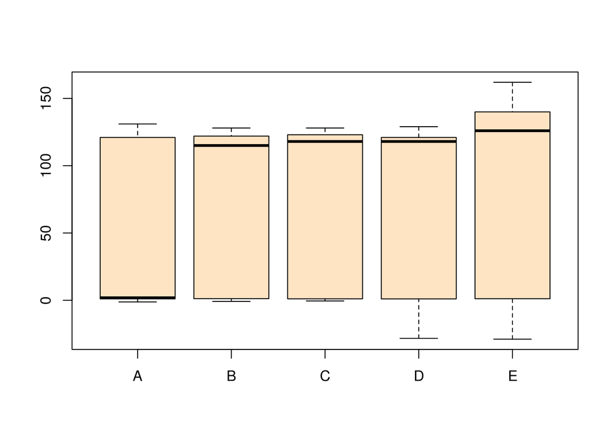

```r
boxplot(roll_belt ~ classe, data = train, col = "bisque")
```

- **Plot 2: *pitch_belt* vs *classe* box plot**

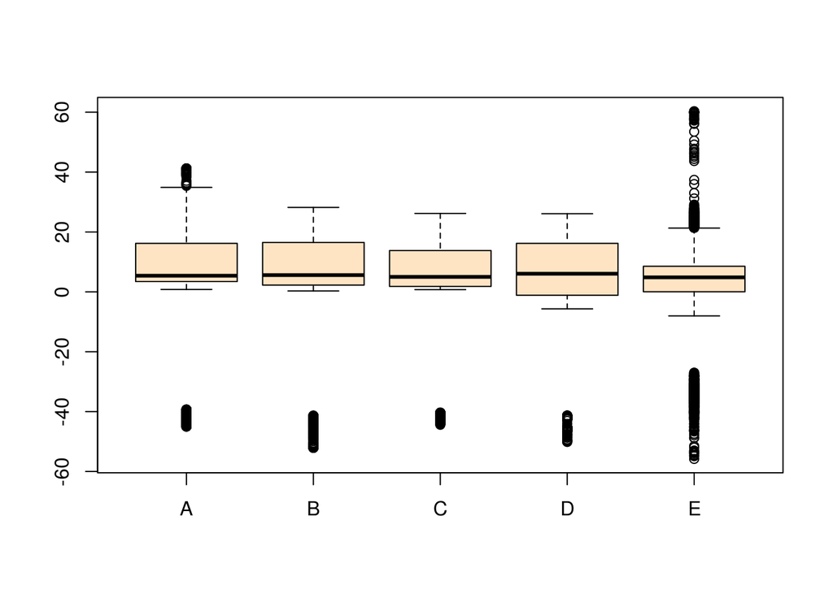

```r
boxplot(pitch_belt ~ classe, data = train, col = "bisque")
```

- **Plot 3: *yaw_belt* vs *classe* box plot**

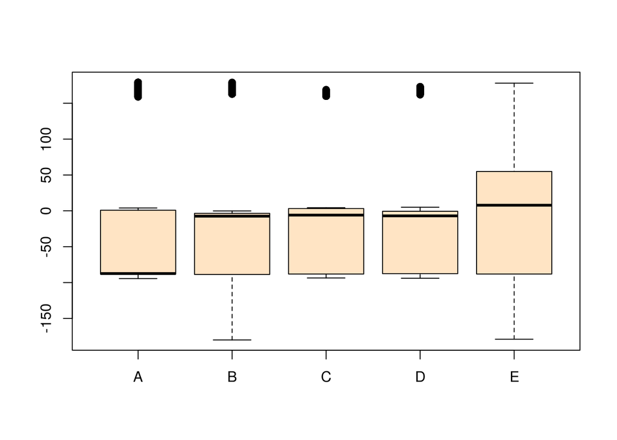

```r
boxplot(yaw_belt ~ classe, data = train, col = "bisque")
```

- **Plot 4: *total_accel_belt* vs *classe* box plot**

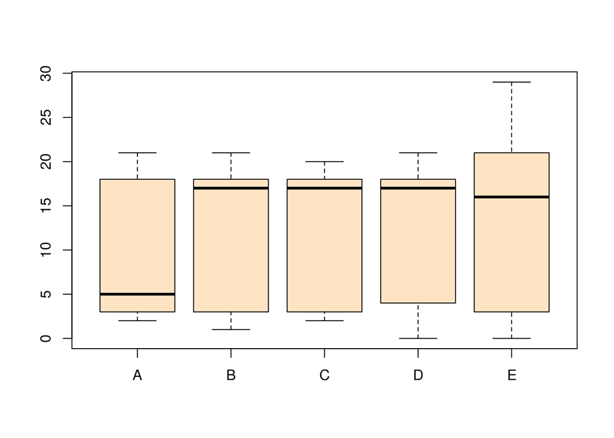

```r
boxplot(total_accel_belt ~ classe, data = train, col = "bisque")
```

- **Plot 5: *magnet_belt_x* vs *classe* box plot**

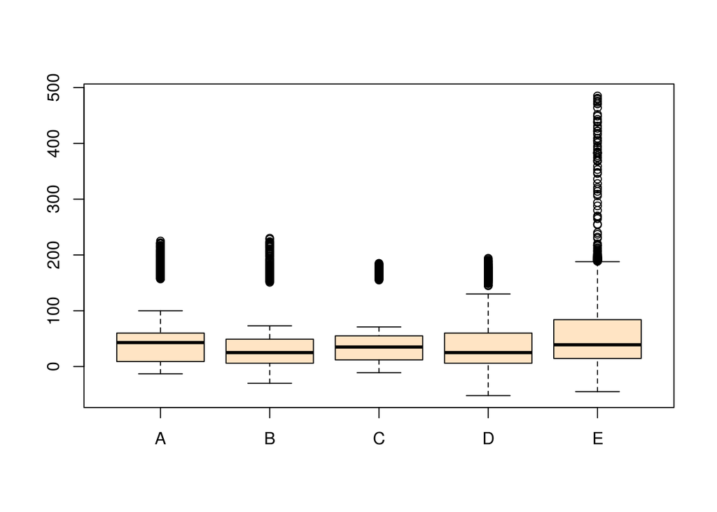

```r
boxplot(magnet_belt_x ~ classe, data = train, col = "bisque")
```

### Filter Dataset

```r
# Select the first column X and columns 3 to 7 which includes timestamps and other unnecessary information
colvec <- c(1,3:7)
# Select columns that have more than 19216 NA values and empty values
filterCol <- function() {
 for (i in 1:length(train))
    if (sum(is.na(x = train[, i])) >= 19216 | sum("" == trimws(train[,i])) >= 19216)
      colvec <- c(colvec, i)
  colvec
}
colvec <- filterCol()

# Apply the column filter
train <- train[,-colvec]
test <- test[,-colvec]

# Check dataset dimensions
dim(train)
```

```
## [1] 19622    54
```

```r
dim(test)
```

```
## [1] 20 54
```

### Fit model with random forest

- **Subset the *train* dataset into *training* and *crossv***

Using the caret package, we will split the *train* dataset into *training* and *crossv* or cross valiation dataset. The cross validation dataset will allows us to check the accuracy of the training model.

```r
# Load caret package
library(caret)

# Use createDataPartition function to split the train dataset into training and crossv
inTrain <- createDataPartition(y = train$classe, p = 0.75, list = FALSE)
training <- train[inTrain, ]
crossv <- train[-inTrain, ]

# Check dataset dimensions
dim(training)
```

```
## [1] 14718    54
```

```r
dim(crossv)
```

```
## [1] 4904   54
```

- **Fit the model**

```r
modelFit <- train(classe ~.,data=training, method="rf",verbose=FALSE)
```

- **Display the model summary**

```r
summary(modelFit)
```

```
##                 Length Class      Mode
## call                5  -none-     call
## type                1  -none-     character
## predicted       14718  factor     numeric
## err.rate         3000  -none-     numeric
## confusion          30  -none-     numeric
## votes           73590  matrix     numeric
## oob.times       14718  -none-     numeric
## classes             5  -none-     character
## importance         57  -none-     numeric
## importanceSD        0  -none-     NULL
## localImportance     0  -none-     NULL
## proximity           0  -none-     NULL
## ntree               1  -none-     numeric
## mtry                1  -none-     numeric
## forest             14  -none-     list
## y               14718  factor     numeric
## test                0  -none-     NULL
## inbag               0  -none-     NULL
## xNames             57  -none-     character
## problemType         1  -none-     character
## tuneValue           1  data.frame list
## obsLevels           5  -none-     character
## param               1  -none-     list
```

### Predict

- **Apply predictions on the cross valiation dataset *crossv***

```r
library(caret)
predictions <- predict(modelFit,newdata=crossv[,-length(crossv)])
```

- **Display the Confusion Matrix**

```r
confusionMatrix(predictions,crossv$classe)
```

```
## Confusion Matrix and Statistics
##
##           Reference
## Prediction    A    B    C    D    E
##          A 1395    0    0    0    0
##          B    0  948    1    0    0
##          C    0    1  853    2    0
##          D    0    0    1  801    0
##          E    0    0    0    1  901
##
## Overall Statistics
##
##                Accuracy : 0.9988
##                  95% CI : (0.9973, 0.9996)
##     No Information Rate : 0.2845
##     P-Value [Acc > NIR] : < 2.2e-16
##
##                   Kappa : 0.9985
##  Mcnemar's Test P-Value : NA
##
## Statistics by Class:
##
##                      Class: A Class: B Class: C Class: D Class: E
## Sensitivity            1.0000   0.9989   0.9977   0.9963   1.0000
## Specificity            1.0000   0.9997   0.9993   0.9998   0.9998
## Pos Pred Value         1.0000   0.9989   0.9965   0.9988   0.9989
## Neg Pred Value         1.0000   0.9997   0.9995   0.9993   1.0000
## Prevalence             0.2845   0.1935   0.1743   0.1639   0.1837
## Detection Rate         0.2845   0.1933   0.1739   0.1633   0.1837
## Detection Prevalence   0.2845   0.1935   0.1746   0.1635   0.1839
## Balanced Accuracy      1.0000   0.9993   0.9985   0.9980   0.9999
```

- **Out of sample error**

```r
missClass = function(values, prediction) {
    sum(prediction != values)/length(values)
}
missClass(crossv$classe, predictions)
```

```
## [1] 0.001223491
```

- **Apply the model to the test values**

```r
predict(modelFit,newdata=test[,-length(test)])
```

```
##  [1] B A B A A E D B A A B C B A E E A B B B
## Levels: A B C D E
```